# Test

Lee, Yeon-Ju

2021 7 20

#### 1번. ‘한국복지패널데이터’(SPSS, koweps_hpc10_2015_beta5.sav)를 로드한 후 필요한 데이터 변수만을 select하여 변수명을 변경하시오. 단 필요한 필드로 성별은 gender, 태어난 연도는 birth, 혼인상태는 marriage, 종교는religion, 월평균임금은 income, 직업코드는 code_job, 지역코드는 code_region로 필드명을 변경한다.

#### 0. 패키지 설치 및 로드하기

```r
library(foreign) # SPSS 파일 불러오기
library(dplyr) # 전처리
library(doBy) # 전처리
```

```r
library(ggplot2) # 시각화
library(readxl) # 엑셀파일 불러오기(code_job의 데이터)
rm(list=ls(all.names = TRUE))
```

#### 1. 데이터 불러와 원하는 필드만 추출

```r
raw_Welfare <- read.spss(file = 'D:/bigData/Download/sharedBigdata/Koweps/Koweps_hpc10_2015_beta1.sav', to.data.frame=TRUE)
dim(raw_Welfare)
```

```
## [1] 16664   957
```

```r
View(raw_Welfare)

raw_welfare <- read.spss('D:/bigData/Download/sharedBigdata/Koweps/Koweps_hpc10_2015_beta6.sav', to.data.frame=TRUE, reencode='utf-8')
```

```
## re-encoding from utf-8
```

```r
dim(raw_welfare)
```

```
## [1] 16664   966
```

```r
View(raw_welfare)

welfare <- raw_welfare[, c('h10_g3','h10_g4','h10_g10','h10_g11','h10_eco9','p1002_8aq1','h10_reg7')]
dim(welfare)
```

```
## [1] 16664     7
```

```r
head(welfare)
```

```
##   h10_g3 h10_g4 h10_g10 h10_g11 h10_eco9 p1002_8aq1 h10_reg7
## 1      2   1936       2       2       NA         NA        1
## 2      2   1945       2       2       NA         NA        1
## 3      1   1948       2       2      942        120        1
## 4      1   1942       3       1      762        200        1
## 5      2   1923       2       1       NA         NA        1
## 6      1   1962       1       1      530         NA        1
```

```r
welfare <- rename(welfare, gender=h10_g3, birth=h10_g4, marriage=h10_g10,
                  religion=h10_g11, code_job=h10_eco9, income=p1002_8aq1, code_region=h10_reg7)
head(welfare)
```

```
##   gender birth marriage religion code_job income code_region
## 1      2  1936        2        2       NA     NA           1
## 2      2  1945        2        2       NA     NA           1
## 3      1  1948        2        2      942    120           1
## 4      1  1942        3        1      762    200           1
## 5      2  1923        2        1       NA     NA           1
## 6      1  1962        1        1      530     NA           1
```

```r
table(is.na(welfare))
```

```
##
## FALSE  TRUE
## 95483 21165
```

```r
colSums(is.na(welfare))
```

```
##      gender       birth    marriage    religion    code_job      income
##           0           0           0           0        9135       12030
## code_region
##           0
```

#### 2번. 1번 문제의 결과인 data.frame변수를 이용하여 성별에 따른 월급 차이가 있는지를 분석하시오.

#### 2. 성별에 따른 월급 차이 분석

```r
# (1) gender필드에 이상이 있는지 확인, 이상치 처리
table(welfare$gender, useNA='ifany') #이상치 없음
```

```
##
##    1    2
## 7574 9090
```

```r
# (2) gender필드 결측치 확인
table(is.na(welfare$gender)) #결측치 없음
```

```
##
## FALSE
## 16664
```

```r
# (3) gender가 1이면 'male'로 2면 'female'로 변경. factor로 변경
welfare$gender <- ifelse(welfare$gender==1, "male","female")
table(welfare$gender)
```

```
##
## female   male
##   9090   7574
```

```r
welfare$gender <- factor(welfare$gender, levels=c('male','female'))
# (4) 성별 비율 도표와 그래프 시각화
gender.ratio <- welfare %>%
  group_by(gender) %>%
  summarise(ratio = n()/nrow(welfare)*100)
gender.ratio
```

```
## # A tibble: 2 x 2
##   gender ratio
##   <fct>  <dbl>
## 1 male    45.5
## 2 female  54.5
```

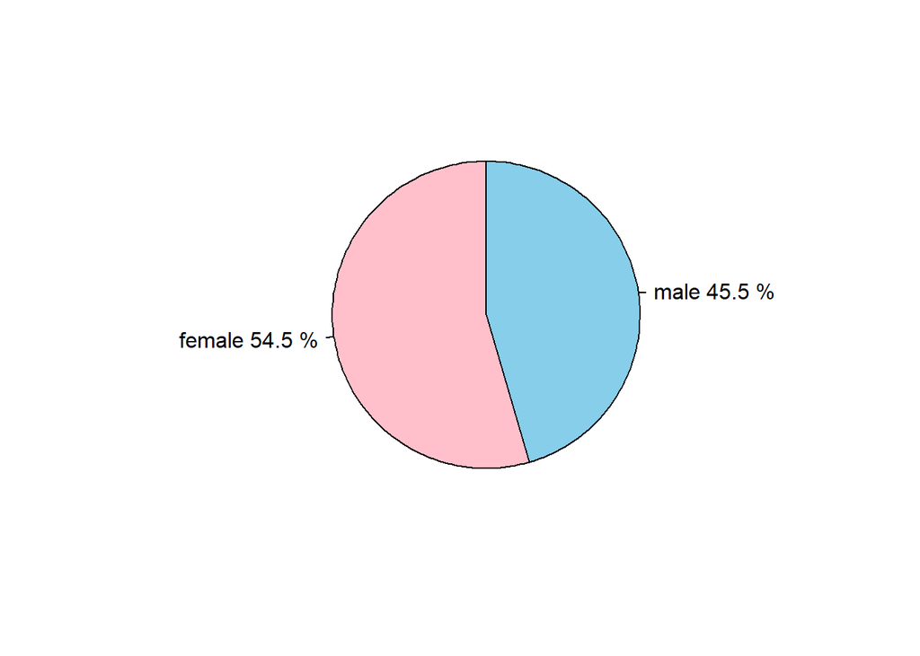

```r
pie(gender.ratio$ratio,
    labels=paste(gender.ratio$gender,round(gender.ratio$ratio, 1),'%'),
    clockwise = T, col=c('skyblue','pink'))
```

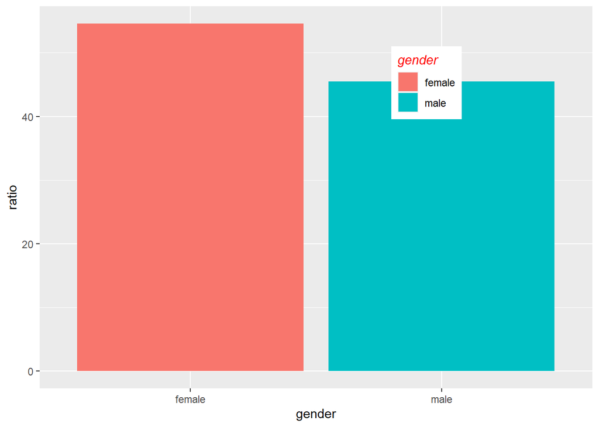

```r
ggplot(gender.ratio, aes(x=gender, y=ratio, fill=gender)) +
  #geom_col() +
  geom_bar(stat='identity') +
  scale_x_discrete(limits=c('female','male')) + #축의 순서 지정
  scale_fill_discrete(limits=c('female','male')) + #범례 순서 지정
  theme(legend.position = c(.7,.8), #범례 위치 지정
        legend.title = element_text(face=3, color='red')) #범례 이탤릭체 빨간글씨
```